# AQUI EL CSV

```python
import pandas as pd
df1 = pd.read_csv('/content/drive/MyDrive/Entrega2/billing.csv')
pd.set_option('display.max_colwidth', None)
df1
```

|  | customerid;billing_date;monthlycharges;internetservice;onlinesecurity;onlinebackup;deviceprotection;techsupport;phone_lines;streaming |
| --- | --- |
| 0 | 3d40ba9d86cc7b97612628a924cd63bc;2023-01-31;29.85;DSL;No;Yes;No;No;0;No |
| 1 | 3d40ba9d86cc7b97612628a924cd63bc;2023-02-28;29.85;DSL;No;Yes;No;No;0;No |
| 2 | 3d40ba9d86cc7b97612628a924cd63bc;2023-03-31;29.85;DSL;No;Yes;No;No;0;No |
| 3 | 3d40ba9d86cc7b97612628a924cd63bc;2023-04-30;35.82;DSL;No;Yes;No;No;0;No |
| 4 | 3d40ba9d86cc7b97612628a924cd63bc;2023-05-31;35.82;DSL;No;Yes;No;No;0;No |
| ... | ... |
| 100775 | 7aea14389aa3d73fd383221574f76778;2023-04-30;70.6;Fiber optic;No;No;No;No;1;No |
| 100776 | 7aea14389aa3d73fd383221574f76778;2023-05-31;70.6;Fiber optic;No;No;No;No;1;No |
| 100777 | 7aea14389aa3d73fd383221574f76778;2023-06-30;70.6;Fiber optic;No;No;No;No;1;No |
| 100778 | 7aea14389aa3d73fd383221574f76778;2023-07-31;70.6;Fiber optic;No;No;No;No;1;No |
| 100779 | 7aea14389aa3d73fd383221574f76778;2023-08-18;70.6;Fiber optic;No;No;No;No;1;No |

100780 rows × 1 columns

Aqui aprecio que la tabla esta un poco rara, que esta separado por punto y coma y que esta todo en una columna, por ende hago una verificacion para ver que es lo que esta ocurriendo aqui

```python
columnas = df1.columns.tolist()
print(columnas)
print(len(columnas))
```

```
['customerid;billing_date;monthlycharges;internetservice;onlinesecurity;onlinebackup;deviceprotection;techsupport;phone_lines;streaming']
1
```

Solucionado :)

```python
df1 = pd.read_csv('/content/drive/MyDrive/Entrega2/billing.csv', sep=';')
df1
```

|  | customerid | billing_date | monthlycharges | internetservice | onlinesecurity | onlinebackup | deviceprotection | techsupport | phone_lines | streaming |
| --- | --- | --- | --- | --- | --- | --- | --- | --- | --- | --- |
| 0 | 3d40ba9d86cc7b97612628a924cd63bc | 2023-01-31 | 29.85 | DSL | No | Yes | No | No | 0 | No |
| 1 | 3d40ba9d86cc7b97612628a924cd63bc | 2023-02-28 | 29.85 | DSL | No | Yes | No | No | 0 | No |
| 2 | 3d40ba9d86cc7b97612628a924cd63bc | 2023-03-31 | 29.85 | DSL | No | Yes | No | No | 0 | No |
| 3 | 3d40ba9d86cc7b97612628a924cd63bc | 2023-04-30 | 35.82 | DSL | No | Yes | No | No | 0 | No |
| 4 | 3d40ba9d86cc7b97612628a924cd63bc | 2023-05-31 | 35.82 | DSL | No | Yes | No | No | 0 | No |
| ... | ... | ... | ... | ... | ... | ... | ... | ... | ... | ... |
| 100775 | 7aea14389aa3d73fd383221574f76778 | 2023-04-30 | 70.60 | Fiber optic | No | No | No | No | 1 | No |
| 100776 | 7aea14389aa3d73fd383221574f76778 | 2023-05-31 | 70.60 | Fiber optic | No | No | No | No | 1 | No |
| 100777 | 7aea14389aa3d73fd383221574f76778 | 2023-06-30 | 70.60 | Fiber optic | No | No | No | No | 1 | No |
| 100778 | 7aea14389aa3d73fd383221574f76778 | 2023-07-31 | 70.60 | Fiber optic | No | No | No | No | 1 | No |
| 100779 | 7aea14389aa3d73fd383221574f76778 | 2023-08-18 | 70.60 | Fiber optic | No | No | No | No | 1 | No |

100780 rows × 10 columns

Hacemos un describe all para ponernos al punto

```python
df1.describe(include='all')
```

|  | customerid | billing_date | monthlycharges | internetservice | onlinesecurity | onlinebackup | deviceprotection | techsupport | phone_lines | streaming |
| --- | --- | --- | --- | --- | --- | --- | --- | --- | --- | --- |
| count | 100780 | 100780 | 100507.000000 | 100501 | 100575 | 100530 | 100562 | 100534 | 100780.000000 | 100780 |
| unique | 11236 | 206 | NaN | 3 | 3 | 3 | 3 | 3 | NaN | 2 |
| top | 3d40ba9d86cc7b97612628a924cd63bc | 2023-01-31 | NaN | Fiber optic | No | No | No | No | NaN | No |
| freq | 10 | 11236 | NaN | 41342 | 46562 | 41615 | 41867 | 46336 | NaN | 51201 |
| mean | NaN | NaN | 65.937841 | NaN | NaN | NaN | NaN | NaN | 1.317682 | NaN |
| std | NaN | NaN | 31.834821 | NaN | NaN | NaN | NaN | NaN | 0.642785 | NaN |
| min | NaN | NaN | 18.250000 | NaN | NaN | NaN | NaN | NaN | 0.000000 | NaN |
| 25% | NaN | NaN | 30.960000 | NaN | NaN | NaN | NaN | NaN | 1.000000 | NaN |
| 50% | NaN | NaN | 70.350000 | NaN | NaN | NaN | NaN | NaN | 1.000000 | NaN |
| 75% | NaN | NaN | 91.150000 | NaN | NaN | NaN | NaN | NaN | 2.000000 | NaN |
| max | NaN | NaN | 142.380000 | NaN | NaN | NaN | NaN | NaN | 2.000000 | NaN |

Me chirria que haya solamente 11236 unicos en la tabla. Entonces haciendo un group by me doy cuneta de que no es informacion respecto a los clientes sino a todas las facturas emitidas y por ello hay algunos que se repiten varias veces.Recalcar que me parece muy interesante que el rango de permanencia de las facturas en 2023 sea desde 3 meses como minimo(puede ir ligado a una permanencia minima).Se puede llegar a entender que no llegue a 12 por que aun no tengo fecha limite de los datos.

```python
df1.groupby('customerid').size().reset_index(name='count').sort_values(by='count', ascending=False)
```

|  | customerid | count |
| --- | --- | --- |
| 0 | 000aa74f2769e670325b6e7e76805954 | 10 |
| 6932 | 9ebecbbefd26b7406f749bba28cf299c | 10 |
| 6935 | 9ed20f555ae0c7ad3cefe93592dce3e4 | 10 |
| 6937 | 9ede25a48f5db5abd3b89c607d620893 | 10 |
| 6940 | 9efcefb4bf53a42d492db93a41c4d87f | 10 |
| ... | ... | ... |
| 2799 | 3f98506c4ec7120371885a5bebfb1f37 | 3 |
| 7958 | b5953067466d1319f338ebd4225e11ba | 3 |
| 2794 | 3f5e723c97f0acfbc77d15da9d7d2376 | 3 |
| 1169 | 1b2fb8b65f8a84c98821cb70522c01c8 | 3 |
| 731 | 112b2e96a1338fb9fd56279ff5129698 | 3 |

11236 rows × 2 columns

Efectivamente en la siguiente tabla apreciamos como las fechas de facturacion van del 31-01-23 hasta el 31-10-23 lo cual resuelve mi duda anterior y refuerza la teoria

```python
df1['billing_date'] = pd.to_datetime(df1['billing_date'])  # Convertir la columna a tipo datetime si aún no lo está
df1 = df1.sort_values(by='billing_date', ascending=True)
df1
```

|  | customerid | billing_date | monthlycharges | internetservice | onlinesecurity | onlinebackup | deviceprotection | techsupport | phone_lines | streaming |
| --- | --- | --- | --- | --- | --- | --- | --- | --- | --- | --- |
| 0 | 3d40ba9d86cc7b97612628a924cd63bc | 2023-01-31 | 29.85 | DSL | No | Yes | No | No | 0 | No |
| 19282 | 28227e725d9f3529776e6cb4e4bb352b | 2023-01-31 | 84.10 | Fiber optic | No | No | No | No | 2 | Yes |
| 71905 | 1e017bf1400190296d3c6304af03482c | 2023-01-31 | 93.55 | Fiber optic | No | No | No | No | 2 | Yes |
| 71897 | f1a5d9be8fb88920dbec1457532174a2 | 2023-01-31 | 69.50 | DSL | Yes | No | Yes | Yes | 1 | Yes |
| 19292 | 782eda53889337eee572483e2344166e | 2023-01-31 | 24.15 | No | No internet service | No internet service | No internet service | No internet service | 2 | No |
| ... | ... | ... | ... | ... | ... | ... | ... | ... | ... | ... |
| 10821 | 112f81a97681425b9be40e100d90b080 | 2023-10-31 | 25.00 | No | No internet service | No internet service | No internet service | No internet service | 2 | No |
| 32141 | 6360ed2b12c4013177c0647bfed0bff5 | 2023-10-31 | 75.00 | Fiber optic | Yes | No | No | No | 1 | No |
| 84558 | f47776e4a6e57d0bdcaa3e0b2e5adb89 | 2023-10-31 | 55.45 | DSL | Yes | Yes | No | No | 1 | No |
| 84568 | 7acf68af2960d6f41bc6ed7ec57b66a0 | 2023-10-31 | 73.44 | DSL | Yes | No | Yes | Yes | 0 | Yes |
| 40392 | f49a2d88545d7e9f9928b4a7b6420071 | 2023-10-31 | 23.88 | No | No internet service | No internet service | No internet service | No internet service | 1 | No |

100780 rows × 10 columns

# AQUI EL PARQUET

```python
df2 = pd.read_parquet('/content/drive/MyDrive/Entrega2/clients.parquet')
df2
```

|  | customerid | gender | paperlessbilling | paymentmethod | children | contract_date | married | birth_date | churn_date | country | zipcode | contract_channel |
| --- | --- | --- | --- | --- | --- | --- | --- | --- | --- | --- | --- | --- |
| 0 | 3d40ba9d86cc7b97612628a924cd63bc | Female | Yes | Electronic check | 0 | 2022-12-22 | Yes | 1975-05-01 | NaT | ES | 14576 | None |
| 1 | ce8db6bfb9d902d89f9dc36eb1fc7df9 | Male | No | Mailed check | 0 | 2020-03-07 | No | 1984-04-01 | NaT | ES | 40071 | Phone |
| 2 | 5cf42e9ba3bfa476bc222bebcf63f1a8 | Male | Yes | Mailed check | 0 | 2022-11-07 | No | 2010-12-07 | 2023-05-13 | ES | 45466 | None |
| 3 | 84f664e4dcfa80ce511615bc91ca6692 | Male | No | Bank transfer (automatic) | 0 | 2019-04-09 | No | 1994-08-08 | NaT | ES | 31420 | None |
| 4 | 0467f23d6b9e7891da40ed53339f5725 | Female | Yes | Electronic check | 0 | 2022-11-06 | No | 1973-08-02 | 2023-08-20 | ES | 10119 | None |
| ... | ... | ... | ... | ... | ... | ... | ... | ... | ... | ... | ... | ... |
| 11264 | 40603cfaa31765822d1555c74653ea60 | Female | Yes | Electronic check | 0 | 2022-12-24 | Yes | 1995-09-28 | NaT | ES | 14576 | None |
| 11265 | 4f7479fd8b8cb089cf02bbe3557c7656 | Male | Yes | Electronic check | 2 | 2022-12-17 | Yes | 1992-08-07 | 2023-06-17 | ES | 19605 | None |
| 11266 | 70c4cda7ec0c8a1c40056b1da9f75403 | Male | No | Bank transfer (automatic) | 0 | 2022-11-09 | No | 2010-04-19 | 2023-08-02 | ES | 26622 | None |
| 11267 | 04608afff3c77e7cd2dfb7827fb656b7 | Male | Yes | Electronic check | 1 | 2021-09-11 | No | 1994-08-25 | NaT | ES | 28496 | None |
| 11268 | 7aea14389aa3d73fd383221574f76778 | Female | Yes | Electronic check | 0 | 2022-12-11 | No | 1964-04-02 | 2023-08-18 | ES | 11510 | None |

11269 rows × 12 columns

```python
columnas = df2.columns.tolist()
print(columnas)
print(len(columnas))
```

```
['customerid', 'gender', 'paperlessbilling', 'paymentmethod', 'children', 'contract_date', 'married', 'birth_date', 'churn_date', 'country', 'zipcode', 'contract_channel']
12
```

Aqui hay una cosa que me ha impactado bastante, y es que esta tabla representa claramente la informacion de los clientes desde el 01-01-2017. Abarca casi 6 años mas que la otra tabla y solamente tiene 33 registros de clientes mas.En este punto se me ocurren varias teorias:

-Se tratan de datos erroneos -Puede que se trate de una compañia de telefonica que comenzo en 2017 con muy pocos clientes y repunto en 2022-23 -Puede que sea tan buena la compañia que nadie quiera irse

Para ver que es lo que ocurre aqui analizaremos las fechas

```python
df2.describe(include='all')
```

|  | customerid | gender | paperlessbilling | paymentmethod | children | contract_date | married | birth_date | churn_date | country | zipcode | contract_channel |
| --- | --- | --- | --- | --- | --- | --- | --- | --- | --- | --- | --- | --- |
| count | 11269 | 11238 | 11242 | 11241 | 11269.000000 | 11236 | 11235 | 11269 | 2958 | 11269 | 11264 | 2753 |
| unique | 11269 | 2 | 2 | 4 | NaN | 1997 | 2 | 8849 | 196 | 2 | 6328 | 3 |
| top | 3d40ba9d86cc7b97612628a924cd63bc | Male | Yes | Electronic check | NaN | 2022-12-27 00:00:00 | No | 1995-08-02 00:00:00 | 2023-06-09 00:00:00 | ES | 35016 | Phone |
| freq | 1 | 5683 | 6626 | 3747 | NaN | 47 | 5813 | 5 | 28 | 11264 | 6 | 1072 |
| first | NaN | NaN | NaN | NaN | NaN | 2017-01-01 00:00:00 | NaN | 1934-01-12 00:00:00 | 2023-03-01 00:00:00 | NaN | NaN | NaN |
| last | NaN | NaN | NaN | NaN | NaN | 2023-01-28 00:00:00 | NaN | 2011-12-28 00:00:00 | 2023-09-28 00:00:00 | NaN | NaN | NaN |
| mean | NaN | NaN | NaN | NaN | 0.447067 | NaN | NaN | NaN | NaN | NaN | NaN | NaN |
| std | NaN | NaN | NaN | NaN | 0.738759 | NaN | NaN | NaN | NaN | NaN | NaN | NaN |
| min | NaN | NaN | NaN | NaN | 0.000000 | NaN | NaN | NaN | NaN | NaN | NaN | NaN |
| 25% | NaN | NaN | NaN | NaN | 0.000000 | NaN | NaN | NaN | NaN | NaN | NaN | NaN |
| 50% | NaN | NaN | NaN | NaN | 0.000000 | NaN | NaN | NaN | NaN | NaN | NaN | NaN |
| 75% | NaN | NaN | NaN | NaN | 1.000000 | NaN | NaN | NaN | NaN | NaN | NaN | NaN |
| max | NaN | NaN | NaN | NaN | 2.000000 | NaN | NaN | NaN | NaN | NaN | NaN | NaN |

Otra cosa extraña es la edad, hay 960 personas que son menores de edad, pueden ser menores que a lo mejor tienen una linea movil que les ha comprado otra persona y estan registrados como clientes. O no creo que haya algun problema en vender un servicio telefonico a un menor que yo sepa, ademas la edad mas temprana es del 2011, asi que tampoco me parece tan grabe

```python
# Asumiendo que 'birth_date' es una columna de tipo datetime, si no, convierte la columna antes de ejecutar esta operación
df2['birth_date'] = pd.to_datetime(df2['birth_date'])

# Crear una nueva columna 'grupo' basada en la condición de nacimiento
df2['grupo'] = df2['birth_date'].apply(lambda x: 'Después de 2006' if x.year > 2006 else 'Antes de 2006')

# Realizar el group by y contar los registros en cada grupo
resultados_groupby = df2.groupby('grupo').size()

resultados_groupby
```

```
grupo
Antes de 2006      10309
Después de 2006      960
dtype: int64
```

```python
df2['contract_date'] = pd.to_datetime(df2['contract_date'])

# Define los límites de los cuartiles basados en las fechas proporcionadas
cuartiles = [
    pd.to_datetime('2017-01-01'),
    pd.to_datetime('2018-01-01'),
    pd.to_datetime('2019-01-01'),
    pd.to_datetime('2020-01-01'),
    pd.to_datetime('2021-01-01'),
    pd.to_datetime('2022-01-01'),
    pd.to_datetime('2023-01-01')
]

# Utiliza pd.cut para asignar cada fecha a su respectivo cuartil
df2['cuartil'] = pd.cut(df2['contract_date'], bins=cuartiles, labels=['Q1', 'Q2', 'Q3', 'Q4', 'Q5', 'Q6'], right=False)

# Cuenta la cantidad de clientes en cada cuartil
cuartiles_counts = df2['cuartil'].value_counts().reset_index().rename(columns={'index': 'Cuartil', 'cuartil': 'Cantidad de Clientes'})
cuartiles_counts
```

|  | Cuartil | Cantidad de Clientes |
| --- | --- | --- |
| 0 | Q6 | 3472 |
| 1 | Q1 | 2252 |
| 2 | Q5 | 1632 |
| 3 | Q4 | 1323 |
| 4 | Q2 | 1314 |
| 5 | Q3 | 1225 |

```python
cuartil_1_df = df2[df2['cuartil'] == 'Q1']
cuartil_1_df
```

|  | customerid | gender | paperlessbilling | paymentmethod | children | contract_date | married | birth_date | churn_date | country | zipcode | contract_channel | grupo | cuartil |
| --- | --- | --- | --- | --- | --- | --- | --- | --- | --- | --- | --- | --- | --- | --- |
| 9 | ef59eb419f267bda49c2714565bb58da | Male | No | Bank transfer (automatic) | 1 | 2017-11-14 | No | 1992-07-28 | NaT | ES | 01162 | None | Antes de 2006 | Q1 |
| 15 | ff1b73a749f2a0405cccb11c5a81ee8d | Female | No | Credit card (automatic) | 1 | 2017-04-03 | Yes | 1973-07-13 | NaT | ES | 39499 | None | Antes de 2006 | Q1 |
| 17 | 5e4ae366c81de8a15182726f11d38caa | Male | No | Bank transfer (automatic) | 1 | 2017-02-22 | No | 1973-07-10 | NaT | ES | 06541 | None | Antes de 2006 | Q1 |
| 28 | 7e3dff09edd3809ef5c7562fbd7f3677 | Male | Yes | Credit card (automatic) | 0 | 2017-01-10 | Yes | 1982-05-11 | NaT | ES | 07345 | Store | Antes de 2006 | Q1 |
| 30 | 5defd080fbbb5c567040f132827589d3 | Female | Yes | Credit card (automatic) | 0 | 2017-02-11 | Yes | 1941-02-23 | NaT | ES | 51185 | None | Antes de 2006 | Q1 |
| ... | ... | ... | ... | ... | ... | ... | ... | ... | ... | ... | ... | ... | ... | ... |
| 11237 | a059c1a6cb33cf97523696422fb84655 | Male | Yes | Bank transfer (automatic) | 0 | 2017-10-16 | No | 1938-04-18 | NaT | ES | 30439 | None | Antes de 2006 | Q1 |
| 11254 | df679ff9eeb81c9ffe07b6622971ae94 | Female | Yes | Bank transfer (automatic) | 0 | 2017-01-04 | Yes | 2006-06-07 | NaT | ES | 42605 | None | Antes de 2006 | Q1 |
| 11255 | 09457d2c94adb9cd8a1d68327c4bb0f6 | Female | Yes | Bank transfer (automatic) | 0 | 2017-01-06 | Yes | 1992-04-28 | NaT | ES | 13254 | None | Antes de 2006 | Q1 |
| 11256 | 15dbe58ff7ff41a2582aa831dccf8c56 | Female | Yes | Credit card (automatic) | 0 | 2017-02-05 | Yes | 1965-09-16 | NaT | ES | 36131 | None | Antes de 2006 | Q1 |
| 11259 | e37166504caae046e4ce2a4791987629 | Female | Yes | Bank transfer (automatic) | 0 | 2017-03-21 | Yes | 2004-07-08 | NaT | ES | 26319 | None | Antes de 2006 | Q1 |

2252 rows × 14 columns

Cada mas que profundizo mas extraño se pone, ahora resulta que les ha ido de puta madre desde 2017, teniendo en cada año una suma importante mas de clientes, y desde 2017 han estado tan contentos que en 6 años no ha habido ni 1 sola persona que haya abandonado.Pero en 2023 parece ser que ha ocurrido algo que les ha rallado y han decido irse en masa.

Es una historia dificil de creerse, en este punto puedo llegar a pensar que los NaT del churn_date son realmente perdidas de informacion y no unicamente que siguen siendo clientes, o puede ser que ambas. Voy a probar con el dataset de Tenure a ver si de ahi puedo sacar algo mas para quitarme de dudas

```python
import pandas as pd

# Supongamos que df2 es tu DataFrame con la columna 'churn_date'
# Asegúrate de que 'churn_date' sea de tipo datetime, si no lo es, conviértelo
df2['churn_date'] = pd.to_datetime(df2['churn_date'])

# Define los límites de los cuartiles basados en las fechas proporcionadas
cuartiles = [
    pd.to_datetime('2017-01-01'),
    pd.to_datetime('2018-01-01'),
    pd.to_datetime('2019-01-01'),
    pd.to_datetime('2020-01-01'),
    pd.to_datetime('2021-01-01'),
    pd.to_datetime('2022-01-01'),
    pd.to_datetime('2023-12-31')
]

# Utiliza pd.cut para asignar cada fecha a su respectivo cuartil
df2['cuartil_churn'] = pd.cut(df2['churn_date'], bins=cuartiles, labels=['Q1', 'Q2', 'Q3', 'Q4', 'Q5', 'Q6'], right=False)

cuartiles_counts_abandono = df2['cuartil_churn'].value_counts().reset_index().rename(columns={'index': 'Cuartil', 'cuartil': 'Cantidad de Abandonos'})
# Muestra el DataFrame resultante
cuartiles_counts_abandono
```

|  | Cuartil | cuartil_churn |
| --- | --- | --- |
| 0 | Q6 | 2958 |
| 1 | Q1 | 0 |
| 2 | Q2 | 0 |
| 3 | Q3 | 0 |
| 4 | Q4 | 0 |
| 5 | Q5 | 0 |

```python
df2
```

|  | customerid | gender | paperlessbilling | paymentmethod | children | contract_date | married | birth_date | churn_date | country | zipcode | contract_channel | grupo | cuartil | cuartil_churn |
| --- | --- | --- | --- | --- | --- | --- | --- | --- | --- | --- | --- | --- | --- | --- | --- |
| 0 | 3d40ba9d86cc7b97612628a924cd63bc | Female | Yes | Electronic check | 0 | 2022-12-22 | Yes | 1975-05-01 | NaT | ES | 14576 | None | Antes de 2006 | Q6 | NaN |
| 1 | ce8db6bfb9d902d89f9dc36eb1fc7df9 | Male | No | Mailed check | 0 | 2020-03-07 | No | 1984-04-01 | NaT | ES | 40071 | Phone | Antes de 2006 | Q4 | NaN |
| 2 | 5cf42e9ba3bfa476bc222bebcf63f1a8 | Male | Yes | Mailed check | 0 | 2022-11-07 | No | 2010-12-07 | 2023-05-13 | ES | 45466 | None | Después de 2006 | Q6 | Q6 |
| 3 | 84f664e4dcfa80ce511615bc91ca6692 | Male | No | Bank transfer (automatic) | 0 | 2019-04-09 | No | 1994-08-08 | NaT | ES | 31420 | None | Antes de 2006 | Q3 | NaN |
| 4 | 0467f23d6b9e7891da40ed53339f5725 | Female | Yes | Electronic check | 0 | 2022-11-06 | No | 1973-08-02 | 2023-08-20 | ES | 10119 | None | Antes de 2006 | Q6 | Q6 |
| ... | ... | ... | ... | ... | ... | ... | ... | ... | ... | ... | ... | ... | ... | ... | ... |
| 11264 | 40603cfaa31765822d1555c74653ea60 | Female | Yes | Electronic check | 0 | 2022-12-24 | Yes | 1995-09-28 | NaT | ES | 14576 | None | Antes de 2006 | Q6 | NaN |
| 11265 | 4f7479fd8b8cb089cf02bbe3557c7656 | Male | Yes | Electronic check | 2 | 2022-12-17 | Yes | 1992-08-07 | 2023-06-17 | ES | 19605 | None | Antes de 2006 | Q6 | Q6 |
| 11266 | 70c4cda7ec0c8a1c40056b1da9f75403 | Male | No | Bank transfer (automatic) | 0 | 2022-11-09 | No | 2010-04-19 | 2023-08-02 | ES | 26622 | None | Después de 2006 | Q6 | Q6 |
| 11267 | 04608afff3c77e7cd2dfb7827fb656b7 | Male | Yes | Electronic check | 1 | 2021-09-11 | No | 1994-08-25 | NaT | ES | 28496 | None | Antes de 2006 | Q5 | NaN |
| 11268 | 7aea14389aa3d73fd383221574f76778 | Female | Yes | Electronic check | 0 | 2022-12-11 | No | 1964-04-02 | 2023-08-18 | ES | 11510 | None | Antes de 2006 | Q6 | Q6 |

11269 rows × 15 columns

# TENURE

Aqui le hecho un vistazo a la tabla de Tenure y vemos que efectivamente solo tiene informacion respecto a los compromisos de permanencia, que nos puede resutar mas util proximamente pero no nos resuelve el problema de lo abandonos. Ya que la permamencia mas larga duro 14 meses y no 6 años para que asi ecnuadre mas o menos los numeros

```python
df3 = pd.read_json('/content/drive/MyDrive/Entrega2/tenure.json')
df3
```

|  | customerid | date | tenure_months | tenure_penalty |
| --- | --- | --- | --- | --- |
| 0 | 3d40ba9d86cc7b97612628a924cd63bc | 2023-01-31 | 6 | 89.17 |
| 1 | 3d40ba9d86cc7b97612628a924cd63bc | 2023-02-28 | 5 | 74.31 |
| 2 | 3d40ba9d86cc7b97612628a924cd63bc | 2023-03-31 | 4 | 59.45 |
| 3 | 3d40ba9d86cc7b97612628a924cd63bc | 2023-04-30 | 3 | 44.59 |
| 4 | 3d40ba9d86cc7b97612628a924cd63bc | 2023-05-31 | 2 | 29.72 |
| ... | ... | ... | ... | ... |
| 26596 | 167041637430b3d83cd801a7c43369c9 | 2023-06-30 | 6 | 63.44 |
| 26597 | 167041637430b3d83cd801a7c43369c9 | 2023-07-31 | 5 | 52.87 |
| 26598 | 167041637430b3d83cd801a7c43369c9 | 2023-08-31 | 4 | 42.30 |
| 26599 | 167041637430b3d83cd801a7c43369c9 | 2023-09-30 | 3 | 31.72 |
| 26600 | 167041637430b3d83cd801a7c43369c9 | 2023-10-31 | 2 | 21.15 |

26601 rows × 4 columns

```python
df3.describe(include='all')
```

|  | customerid | date | tenure_months | tenure_penalty |
| --- | --- | --- | --- | --- |
| count | 26601 | 26601 | 26601.000000 | 26601.000000 |
| unique | 4189 | 76 | NaN | NaN |
| top | 167041637430b3d83cd801a7c43369c9 | 2023-01-31 00:00:00 | NaN | NaN |
| freq | 10 | 4189 | NaN | NaN |
| first | NaN | 2023-01-31 00:00:00 | NaN | NaN |
| last | NaN | 2023-10-31 00:00:00 | NaN | NaN |
| mean | NaN | NaN | 5.459156 | 98.184654 |
| std | NaN | NaN | 3.370749 | 67.184301 |
| min | NaN | NaN | 1.000000 | 10.000000 |
| 25% | NaN | NaN | 3.000000 | 44.500000 |
| 50% | NaN | NaN | 5.000000 | 84.040000 |
| 75% | NaN | NaN | 8.000000 | 138.460000 |
| max | NaN | NaN | 14.000000 | 362.300000 |

Dicho esto, que soluciones propongo.En primera instancia dadas las condiciones de los datasets voy a realizar la siguiente comprobacion para corrobar si mi teoria de los NaT puede ser cierta o no. Para ello se me ha ocurrido aprovechar el datframe de billing, lo que voy a hacer es un count de las personas que hayan recibido una factura el dia 31-10-2023, lo que significara que aun siguen bajo contrato y no ha habido abandono. A continuacion hare un coun de NaT en la columna de churn_date y a partir de si uno es mayor,meno o igual que el otro, entonces tomare una decision.

```python
df1_selected = df1[df1['billing_date'] == '2023-10-31']
df1_selected
```

|  | customerid | billing_date | monthlycharges | internetservice | onlinesecurity | onlinebackup | deviceprotection | techsupport | phone_lines | streaming |
| --- | --- | --- | --- | --- | --- | --- | --- | --- | --- | --- |
| 81358 | f4ef2bad1c78c3cd08b1606091eca24b | 2023-10-31 | 19.45 | No | No internet service | No internet service | No internet service | No internet service | 0 | No |
| 36516 | 41bdbf1103764c80b08f4e571806e1fa | 2023-10-31 | 114.96 | Fiber optic | No | No | No | No | 2 | Yes |
| 82446 | 230bc44c2e2265f47d1558cfb28ef520 | 2023-10-31 | 119.82 | Fiber optic | No | Yes | Yes | No | 1 | Yes |
| 81254 | fd09cf71ec9933fab1cb07ae7b00bd63 | 2023-10-31 | 19.50 | No | No internet service | No internet service | No internet service | No internet service | 1 | No |
| 46021 | 071c0a66cd4c1945187f28b21e092670 | 2023-10-31 | 116.50 | Fiber optic | Yes | Yes | Yes | Yes | 2 | Yes |
| ... | ... | ... | ... | ... | ... | ... | ... | ... | ... | ... |
| 10821 | 112f81a97681425b9be40e100d90b080 | 2023-10-31 | 25.00 | No | No internet service | No internet service | No internet service | No internet service | 2 | No |
| 32141 | 6360ed2b12c4013177c0647bfed0bff5 | 2023-10-31 | 75.00 | Fiber optic | Yes | No | No | No | 1 | No |
| 84558 | f47776e4a6e57d0bdcaa3e0b2e5adb89 | 2023-10-31 | 55.45 | DSL | Yes | Yes | No | No | 1 | No |
| 84568 | 7acf68af2960d6f41bc6ed7ec57b66a0 | 2023-10-31 | 73.44 | DSL | Yes | No | Yes | Yes | 0 | Yes |
| 40392 | f49a2d88545d7e9f9928b4a7b6420071 | 2023-10-31 | 23.88 | No | No internet service | No internet service | No internet service | No internet service | 1 | No |

8278 rows × 10 columns

Sorprendentemente, y ante cualquier pronostico el dataframe no tiene perdidas de informacion o datos erroneos. Y aun que cueste creerse la historia de que durante 6 años no hubo ni un solo abandono, teniendo en cuenta que el compromiso de permanencia mas alto que habido es de 14 meses, y que justo por casualidad, entre el mes 2 y 10 de 2023 hubieron 2958 abandonos de repente. Aun que cueste creerselo, y parezca muy hipotetico, toca achantar la cabeza y creerselo. Ya que creo que ya he realizado suificientes analisis para rebocar que relamente son veridicos. Y no tiene sentido seguir forzandolo unicemente por que me parezca anomalo.

```python
# Supongamos que df2 es tu DataFrame
nan_count_churn_date = df2['churn_date'].isna().sum()

# Muestra el resultado
print("Cantidad de NaN en churn_date:", nan_count_churn_date)
print(nan_count_churn_date-8278)
```

```
Cantidad de NaN en churn_date: 8311
33
```

Dicho esto, ya habiendo trabajado con los datos y asegurarnos de que podemos trabajar con ellos pasamos al analisis e intenrar resolver las cuestiones.

Para ver cual es el segmento que genera la principal fuente de ingresos en la compania he hecho lo siguiente. En el que se ve como en el resultado su principal grupo de clienta es:

1. Aquellas personas que tienen contratada fibra optica , por lo menos una linea movil y servicio de streaming(Cantidad:29177 Dinero:2929978.3699999996)
2. Aquellas personas que solo tienen contratadas por lo menos una linea movil:(Cantidad:34865 Dinero:1177380.9000000001)
3. Aquellas personas que tienen por lo menos una linea movil y streaming(Cantidad:14841 Dinero:1126264.17)

```python
import pandas as pd

# Supongamos que df1 es tu DataFrame
# Asegúrate de que las columnas relevantes tengan el formato adecuado

# Variables relevantes
features = ['monthlycharges', 'internetservice', 'phone_lines', 'streaming']

# Filtra el DataFrame para incluir solo las columnas relevantes
df1_filtered = df1[features]

# Define condiciones para segmentar
condition1 = df1_filtered['internetservice'] == 'Fiber optic'  # Puedes ajustar esto según tu necesidad
condition2 = df1_filtered['phone_lines'] > 0  # Puedes ajustar esto según tu necesidad
condition3 = df1_filtered['streaming'] == 'Yes'  # Puedes ajustar esto según tu necesidad

# Aplica las condiciones para crear segmentos
segment1 = df1_filtered[condition1 & condition2 & condition3]
segment2 = df1_filtered[~condition1 & condition2 & condition3]
segment3 = df1_filtered[condition1 & ~condition2 & condition3]
segment4 = df1_filtered[condition1 & condition2 & ~condition3]
segment5 = df1_filtered[~condition1 & ~condition2 & condition3]
segment6 = df1_filtered[condition1 & ~condition2 & ~condition3]
segment7 = df1_filtered[~condition1 & condition2 & ~condition3]
segment8 = df1_filtered[~condition1 & ~condition2 & ~condition3]

# Agrega la información de la suma de monthlycharges a cada segmento
segment1_sum = segment1['monthlycharges'].sum()
segment2_sum = segment2['monthlycharges'].sum()
segment3_sum = segment3['monthlycharges'].sum()
segment4_sum = segment4['monthlycharges'].sum()
segment5_sum = segment5['monthlycharges'].sum()
segment6_sum = segment6['monthlycharges'].sum()
segment7_sum = segment7['monthlycharges'].sum()
segment8_sum = segment8['monthlycharges'].sum()

# Muestra el tamaño y la suma de monthlycharges de cada segmento
print("Tamaño del segmento 1:", len(segment1), "Suma de monthlycharges:", segment1_sum)
print("Tamaño del segmento 2:", len(segment2), "Suma de monthlycharges:", segment2_sum)
print("Tamaño del segmento 3:", len(segment3), "Suma de monthlycharges:", segment3_sum)
print("Tamaño del segmento 4:", len(segment4), "Suma de monthlycharges:", segment4_sum)
print("Tamaño del segmento 5:", len(segment5), "Suma de monthlycharges:", segment5_sum)
print("Tamaño del segmento 6:", len(segment6), "Suma de monthlycharges:", segment6_sum)
print("Tamaño del segmento 7:", len(segment7), "Suma de monthlycharges:", segment7_sum)
print("Tamaño del segmento 8:", len(segment8), "Suma de monthlycharges:", segment8_sum)

print(len(segment1)+len(segment2)+len(segment3)+len(segment4)+len(segment5)+len(segment6)+len(segment7)+len(segment8))
```

```
Tamaño del segmento 1: 29177 Suma de monthlycharges: 2929978.37
Tamaño del segmento 2: 14841 Suma de monthlycharges: 1126264.17
Tamaño del segmento 3: 83 Suma de monthlycharges: 5978.240000000001
Tamaño del segmento 4: 12000 Suma de monthlycharges: 950194.0
Tamaño del segmento 5: 5478 Suma de monthlycharges: 286474.28
Tamaño del segmento 6: 82 Suma de monthlycharges: 5346.51
Tamaño del segmento 7: 34865 Suma de monthlycharges: 1177380.9
Tamaño del segmento 8: 4254 Suma de monthlycharges: 145598.1
100780
```

Para saber que es lo que caracteriza mas a las personas propensas a irse primero voy a obtener la tabla unicamente de estas personas.

```python
# Supongamos que df2 es tu DataFrame
df2_not_null_churn_date = df2[df2['churn_date'].notna()]

# Muestra el DataFrame resultante
df2_not_null_churn_date
```

|  | customerid | gender | paperlessbilling | paymentmethod | children | contract_date | married | birth_date | churn_date | country | zipcode | contract_channel | grupo | cuartil | cuartil_churn |
| --- | --- | --- | --- | --- | --- | --- | --- | --- | --- | --- | --- | --- | --- | --- | --- |
| 2 | 5cf42e9ba3bfa476bc222bebcf63f1a8 | Male | Yes | Mailed check | 0 | 2022-11-07 | No | 2010-12-07 | 2023-05-13 | ES | 45466 | None | Después de 2006 | Q6 | Q6 |
| 4 | 0467f23d6b9e7891da40ed53339f5725 | Female | Yes | Electronic check | 0 | 2022-11-06 | No | 1973-08-02 | 2023-08-20 | ES | 10119 | None | Antes de 2006 | Q6 | Q6 |
| 5 | a3eb2b52fe0a63d2351819270bcedbf6 | Female | Yes | Electronic check | 0 | 2022-05-17 | No | 2010-11-26 | 2023-09-08 | ES | 31255 | None | Después de 2006 | Q6 | Q6 |
| 8 | b6e3534f9b289114eab3721f4cf6f2f9 | Female | Yes | Electronic check | 0 | 2020-09-08 | Yes | 1977-01-08 | 2023-03-04 | ES | 40269 | None | Antes de 2006 | Q4 | Q6 |
| 13 | 34af156cf33959c65838f86c0c9b645b | Male | Yes | Bank transfer (automatic) | 0 | 2018-12-25 | No | 1972-02-05 | 2023-06-08 | ES | 38075 | None | Antes de 2006 | Q2 | Q6 |
| ... | ... | ... | ... | ... | ... | ... | ... | ... | ... | ... | ... | ... | ... | ... | ... |
| 11253 | e8f2f4b4da13b8d358fadef0cc4d63e4 | Female | Yes | Credit card (automatic) | 0 | 2022-08-19 | No | 1944-01-03 | 2023-05-27 | ES | 08554 | None | Antes de 2006 | Q6 | Q6 |
| 11260 | 8de6221b3997dc1713808dcffcb437e5 | Male | Yes | Electronic check | 0 | 2022-12-08 | Yes | 1972-05-16 | 2023-08-18 | ES | 08471 | None | Antes de 2006 | Q6 | Q6 |
| 11265 | 4f7479fd8b8cb089cf02bbe3557c7656 | Male | Yes | Electronic check | 2 | 2022-12-17 | Yes | 1992-08-07 | 2023-06-17 | ES | 19605 | None | Antes de 2006 | Q6 | Q6 |
| 11266 | 70c4cda7ec0c8a1c40056b1da9f75403 | Male | No | Bank transfer (automatic) | 0 | 2022-11-09 | No | 2010-04-19 | 2023-08-02 | ES | 26622 | None | Después de 2006 | Q6 | Q6 |
| 11268 | 7aea14389aa3d73fd383221574f76778 | Female | Yes | Electronic check | 0 | 2022-12-11 | No | 1964-04-02 | 2023-08-18 | ES | 11510 | None | Antes de 2006 | Q6 | Q6 |

2958 rows × 15 columns

Antes de pasar con el analisis, vamos a hacer una limpieza ya que a simple vista veo que hay algunos NaN.

```python
df2_not_null_churn_date.describe(include='all')
```

|  | customerid | gender | paperlessbilling | paymentmethod | children | contract_date | married | birth_date | churn_date | country | zipcode | contract_channel | grupo | cuartil | cuartil_churn |
| --- | --- | --- | --- | --- | --- | --- | --- | --- | --- | --- | --- | --- | --- | --- | --- |
| count | 2958 | 2947 | 2952 | 2950 | 2958.000000 | 2958 | 2948 | 2958 | 2958 | 2958 | 2957 | 724 | 2958 | 2957 | 2958 |
| unique | 2958 | 2 | 2 | 4 | NaN | 1207 | 2 | 2785 | 196 | 2 | 1862 | 3 | 2 | 6 | 1 |
| top | 5cf42e9ba3bfa476bc222bebcf63f1a8 | Female | Yes | Electronic check | NaN | 2022-12-27 00:00:00 | No | 1964-03-25 00:00:00 | 2023-06-09 00:00:00 | ES | 04175 | Phone | Antes de 2006 | Q6 | Q6 |
| freq | 1 | 1477 | 2194 | 1656 | NaN | 31 | 1871 | 4 | 28 | 2957 | 6 | 279 | 2735 | 1623 | 2958 |
| first | NaN | NaN | NaN | NaN | NaN | 2017-01-01 00:00:00 | NaN | 1934-02-14 00:00:00 | 2023-03-01 00:00:00 | NaN | NaN | NaN | NaN | NaN | NaN |
| last | NaN | NaN | NaN | NaN | NaN | 2023-01-24 00:00:00 | NaN | 2011-12-22 00:00:00 | 2023-09-28 00:00:00 | NaN | NaN | NaN | NaN | NaN | NaN |
| mean | NaN | NaN | NaN | NaN | 0.268763 | NaN | NaN | NaN | NaN | NaN | NaN | NaN | NaN | NaN | NaN |
| std | NaN | NaN | NaN | NaN | 0.610840 | NaN | NaN | NaN | NaN | NaN | NaN | NaN | NaN | NaN | NaN |
| min | NaN | NaN | NaN | NaN | 0.000000 | NaN | NaN | NaN | NaN | NaN | NaN | NaN | NaN | NaN | NaN |
| 25% | NaN | NaN | NaN | NaN | 0.000000 | NaN | NaN | NaN | NaN | NaN | NaN | NaN | NaN | NaN | NaN |
| 50% | NaN | NaN | NaN | NaN | 0.000000 | NaN | NaN | NaN | NaN | NaN | NaN | NaN | NaN | NaN | NaN |
| 75% | NaN | NaN | NaN | NaN | 0.000000 | NaN | NaN | NaN | NaN | NaN | NaN | NaN | NaN | NaN | NaN |
| max | NaN | NaN | NaN | NaN | 2.000000 | NaN | NaN | NaN | NaN | NaN | NaN | NaN | NaN | NaN | NaN |

Obviamente descartamos contract_channel para ver los NaN.

Tambien otra cosa muy curiosa y que no me di cuenta antes. Y es que se me ha colado un portuges. Por ende a ese me lo cargo.

```python
columnas_sin_contract_channel = df2_not_null_churn_date.columns.difference(['contract_channel'])
filas_con_nan = df2_not_null_churn_date[df2_not_null_churn_date[columnas_sin_contract_channel].isna().any(axis=1)]
filas_con_nan
```

|  | customerid | gender | paperlessbilling | paymentmethod | children | contract_date | married | birth_date | churn_date | country | zipcode | contract_channel | grupo | cuartil | cuartil_churn |
| --- | --- | --- | --- | --- | --- | --- | --- | --- | --- | --- | --- | --- | --- | --- | --- |
| 2324 | f6672f00f1d4aaa8a51245bb1e80ccb4 | Female | Yes | Electronic check | 0 | 2021-10-09 | Yes | 1963-10-16 | 2023-05-07 | PT | None | None | Antes de 2006 | Q5 | Q6 |
| 7083 | 94981fdd0d703aeb9e7a7875658e22d5 | None | Yes | Electronic check | 1 | 2021-08-16 | Yes | 1984-01-13 | 2023-08-13 | ES | 30552 | None | Antes de 2006 | Q5 | Q6 |
| 7175 | fe581359a3792eca9f6201bc4ed6022e | Female | No | None | 0 | 2018-07-24 | Yes | 2006-02-27 | 2023-03-05 | ES | 48303 | None | Antes de 2006 | Q2 | Q6 |
| 7176 | e7708928ec4b377a88e8283ad6db58e7 | Female | Yes | Electronic check | 0 | 2022-04-05 | None | 1957-03-12 | 2023-07-19 | ES | 38043 | None | Antes de 2006 | Q6 | Q6 |
| 7283 | 68db2357f9c71df691fa8d6c6d53b28a | None | Yes | Mailed check | 0 | 2022-12-18 | No | 2011-11-17 | 2023-08-24 | ES | 28188 | None | Después de 2006 | Q6 | Q6 |
| 7337 | 4a7befa194a710f5b9dc87ee881a5b38 | Male | Yes | None | 0 | 2017-04-20 | No | 1968-10-26 | 2023-07-24 | ES | 44497 | None | Antes de 2006 | Q1 | Q6 |
| 7430 | 0dd6442fe48cc7f1a0e7e7cd1833ec58 | None | Yes | Credit card (automatic) | 0 | 2017-09-25 | No | 2006-07-23 | 2023-04-11 | ES | 01485 | None | Antes de 2006 | Q1 | Q6 |
| 7551 | 89eb8deca2b6c9bc74f5f50ed5a4229a | Female | Yes | None | 0 | 2022-07-09 | No | 1936-07-25 | 2023-04-12 | ES | 38506 | None | Antes de 2006 | Q6 | Q6 |
| 7591 | 716ba76238e17eb10e1b62c8825e7c73 | Male | No | None | 0 | 2022-08-23 | No | 1993-01-12 | 2023-09-10 | ES | 35483 | None | Antes de 2006 | Q6 | Q6 |
| 7880 | 9424b835d6b0607a32caa282bb658040 | Male | Yes | Electronic check | 0 | 2021-01-09 | None | 1954-04-26 | 2023-06-19 | ES | 26601 | None | Antes de 2006 | Q5 | Q6 |
| 8166 | 19c44f9492062f2b41884bcc92c0529d | None | Yes | Electronic check | 0 | 2017-05-25 | No | 1960-12-26 | 2023-07-19 | ES | 02189 | None | Antes de 2006 | Q1 | Q6 |
| 8183 | e9fcf5d5141f4a9cb7df373d0b7c5bc6 | None | No | Bank transfer (automatic) | 0 | 2021-01-23 | Yes | 1939-05-17 | 2023-08-08 | ES | 25379 | None | Antes de 2006 | Q5 | Q6 |
| 8226 | 457e963d26e84fb5bf19fc3874781839 | Female | No | Mailed check | 2 | 2023-01-24 | Yes | 1987-02-08 | 2023-07-23 | ES | 13547 | None | Antes de 2006 | NaN | Q6 |
| 8333 | df0dedff599cad945a3dbaba0bf10171 | None | No | Electronic check | 0 | 2018-12-15 | Yes | 1983-12-23 | 2023-03-08 | ES | 20371 | None | Antes de 2006 | Q2 | Q6 |
| 8385 | 456f9e16ef7365c9476f53a961a26b1f | Male | None | Mailed check | 1 | 2022-12-16 | No | 1996-12-20 | 2023-09-09 | ES | 23424 | None | Antes de 2006 | Q6 | Q6 |
| 8617 | ee3407ce4c540ab9beb47613e0e43241 | Female | Yes | Electronic check | 0 | 2022-11-19 | None | 2008-10-08 | 2023-07-05 | ES | 46454 | None | Después de 2006 | Q6 | Q6 |
| 8758 | f73f6f5a383e1cd120fb1bcc8ea6892a | Female | None | Bank transfer (automatic) | 0 | 2019-08-25 | Yes | 1938-12-16 | 2023-04-21 | ES | 35155 | None | Antes de 2006 | Q3 | Q6 |
| 8825 | 954be26fa86dd0ace8e60ddd0ae4c465 | Male | Yes | None | 0 | 2022-08-24 | No | 1995-12-17 | 2023-07-01 | ES | 51531 | None | Antes de 2006 | Q6 | Q6 |
| 9001 | 54b9383986d3c1a8189197439b9e7b1c | Male | Yes | Electronic check | 0 | 2022-10-13 | None | 2006-08-19 | 2023-06-27 | ES | 51622 | None | Antes de 2006 | Q6 | Q6 |
| 9025 | 9779f38da4d4ba087d06743b3663b11f | None | No | Electronic check | 0 | 2017-01-01 | Yes | 1993-02-22 | 2023-07-10 | ES | 23260 | None | Antes de 2006 | Q1 | Q6 |
| 9088 | dfbfb046c273c1cf04a77049db6a8380 | Female | Yes | Credit card (automatic) | 0 | 2022-10-27 | None | 1986-10-03 | 2023-05-16 | ES | 13538 | None | Antes de 2006 | Q6 | Q6 |
| 9293 | 1aa169dd11dbac6dbaa92b7f9d1252c7 | None | Yes | Mailed check | 0 | 2022-06-19 | No | 1983-02-02 | 2023-04-08 | ES | 35618 | None | Antes de 2006 | Q6 | Q6 |
| 9454 | 3d514fc7bc13df7c2844732a2d328893 | Female | Yes | None | 0 | 2021-07-08 | No | 1984-11-08 | 2023-04-28 | ES | 35539 | None | Antes de 2006 | Q5 | Q6 |
| 9612 | d3deb387d4b777311962cf2db520e7ff | Female | None | Electronic check | 0 | 2022-12-14 | Yes | 1946-09-05 | 2023-08-23 | ES | 10594 | None | Antes de 2006 | Q6 | Q6 |
| 9742 | 58f48f35d57d7b340fb50338c8d0d717 | Male | No | None | 0 | 2022-12-24 | No | 1966-02-12 | 2023-09-01 | ES | 02509 | None | Antes de 2006 | Q6 | Q6 |
| 9753 | 06dbde7ec21409012c11cc3447a4ad2f | None | Yes | Mailed check | 0 | 2021-09-15 | No | 2002-06-22 | 2023-07-24 | ES | 30278 | None | Antes de 2006 | Q5 | Q6 |
| 10274 | 839898a35eac6774a243e246ba7edaa0 | Male | Yes | Credit card (automatic) | 0 | 2018-05-25 | None | 1965-06-07 | 2023-09-23 | ES | 10240 | None | Antes de 2006 | Q2 | Q6 |
| 10288 | a9aa666a3d6f89977366a38617a4c876 | Male | Yes | Electronic check | 0 | 2018-06-03 | None | 1964-11-03 | 2023-06-05 | ES | 30113 | None | Antes de 2006 | Q2 | Q6 |
| 10346 | e9026ecfd9919b9e98d95b208fceb768 | Female | Yes | Electronic check | 0 | 2022-08-12 | None | 1989-02-09 | 2023-06-27 | ES | 16058 | None | Antes de 2006 | Q6 | Q6 |
| 10347 | 6906a733bfa4c5d0e7c9b9e4f615033d | Female | No | None | 0 | 2022-12-27 | No | 2005-02-28 | 2023-03-19 | ES | 42438 | None | Antes de 2006 | Q6 | Q6 |
| 10601 | 6858b84ec9033baef7bbb630ced58a3f | Male | None | Electronic check | 0 | 2019-08-24 | Yes | 1942-06-25 | 2023-08-04 | ES | 33345 | None | Antes de 2006 | Q3 | Q6 |
| 10840 | eca9f962f9ffc7ce4d696f8dd784e0f2 | None | Yes | Bank transfer (automatic) | 0 | 2022-04-02 | No | 1988-04-03 | 2023-08-09 | ES | 16141 | None | Antes de 2006 | Q6 | Q6 |
| 11032 | ef13975b1db37f38295c84f0949c358c | None | Yes | Bank transfer (automatic) | 1 | 2019-06-07 | Yes | 1942-07-14 | 2023-07-15 | ES | 03043 | None | Antes de 2006 | Q3 | Q6 |
| 11058 | 68c402d308ef3b88f47e3218ef7cf435 | Male | Yes | Mailed check | 0 | 2021-01-08 | None | 1975-01-01 | 2023-07-08 | ES | 45488 | None | Antes de 2006 | Q5 | Q6 |
| 11124 | 4739b1f064fe473574e4f39eabb5aff4 | Female | None | Bank transfer (automatic) | 0 | 2020-10-17 | No | 1981-04-19 | 2023-03-16 | ES | 20337 | None | Antes de 2006 | Q4 | Q6 |
| 11139 | 10137f99521718bb4c7758fd5b9b4ce5 | Male | Yes | Electronic check | 0 | 2022-08-22 | None | 1998-07-07 | 2023-06-11 | ES | 12582 | None | Antes de 2006 | Q6 | Q6 |
| 11209 | 2770f91132e272b0c728550c542f01ed | Male | None | Credit card (automatic) | 0 | 2022-10-17 | Yes | 1972-11-04 | 2023-06-02 | ES | 12384 | None | Antes de 2006 | Q6 | Q6 |

Para solucionar esto, podria cargarme todos los registros que tengan por lo menos un NaN, por que son realmente pocos. Pero decido rellenar el hueco con la moda que creo que seria lo mas indicado. Y como vemos en el Describe que el problema ya esta solucionado y el dataset preparado para emplear.

```python
# Llenar NaN con la moda en cada columna de columnas_sin_contract_channel en df2_not_null_churn_date
for columna in columnas_sin_contract_channel:
    moda = df2_not_null_churn_date[columna].mode()
    if not moda.empty:
        moda_valor = moda.iloc[0]
        df2_not_null_churn_date[columna].fillna(moda_valor, inplace=True)

# Verificar si 'country' es una columna antes de filtrar
if 'country' in columnas_sin_contract_channel:
    df2_not_null_churn_date = df2_not_null_churn_date[df2_not_null_churn_date['country'] != 'PT']
```

```python
df2_not_null_churn_date.describe(include='all')
```

|  | customerid | gender | paperlessbilling | paymentmethod | children | contract_date | married | birth_date | churn_date | country | zipcode | contract_channel | grupo | cuartil | cuartil_churn |
| --- | --- | --- | --- | --- | --- | --- | --- | --- | --- | --- | --- | --- | --- | --- | --- |
| count | 2957 | 2957 | 2957 | 2957 | 2957.000000 | 2957 | 2957 | 2957 | 2957 | 2957 | 2957 | 724 | 2957 | 2957 | 2957 |
| unique | 2957 | 2 | 2 | 4 | NaN | 1207 | 2 | 2784 | 196 | 1 | 1862 | 3 | 2 | 6 | 1 |
| top | 5cf42e9ba3bfa476bc222bebcf63f1a8 | Female | Yes | Electronic check | NaN | 2022-12-27 00:00:00 | No | 1964-03-25 00:00:00 | 2023-06-09 00:00:00 | ES | 04175 | Phone | Antes de 2006 | Q6 | Q6 |
| freq | 1 | 1487 | 2199 | 1663 | NaN | 31 | 1881 | 4 | 28 | 2957 | 6 | 279 | 2734 | 1624 | 2957 |
| first | NaN | NaN | NaN | NaN | NaN | 2017-01-01 00:00:00 | NaN | 1934-02-14 00:00:00 | 2023-03-01 00:00:00 | NaN | NaN | NaN | NaN | NaN | NaN |
| last | NaN | NaN | NaN | NaN | NaN | 2023-01-24 00:00:00 | NaN | 2011-12-22 00:00:00 | 2023-09-28 00:00:00 | NaN | NaN | NaN | NaN | NaN | NaN |
| mean | NaN | NaN | NaN | NaN | 0.268854 | NaN | NaN | NaN | NaN | NaN | NaN | NaN | NaN | NaN | NaN |
| std | NaN | NaN | NaN | NaN | 0.610924 | NaN | NaN | NaN | NaN | NaN | NaN | NaN | NaN | NaN | NaN |
| min | NaN | NaN | NaN | NaN | 0.000000 | NaN | NaN | NaN | NaN | NaN | NaN | NaN | NaN | NaN | NaN |
| 25% | NaN | NaN | NaN | NaN | 0.000000 | NaN | NaN | NaN | NaN | NaN | NaN | NaN | NaN | NaN | NaN |
| 50% | NaN | NaN | NaN | NaN | 0.000000 | NaN | NaN | NaN | NaN | NaN | NaN | NaN | NaN | NaN | NaN |
| 75% | NaN | NaN | NaN | NaN | 0.000000 | NaN | NaN | NaN | NaN | NaN | NaN | NaN | NaN | NaN | NaN |
| max | NaN | NaN | NaN | NaN | 2.000000 | NaN | NaN | NaN | NaN | NaN | NaN | NaN | NaN | NaN | NaN |

Un punto a analizar, que es interesante es ver si tienen hijos y como influye este segun la edad. Ya que el interes de permanencia del cliente no recaera solamente en la decision de una unica perosona.

```python
import pandas as pd
import matplotlib.pyplot as plt

# Asumiendo que 'birth_date' es una columna de tipo datetime, si no, convierte la columna antes de ejecutar esta operación
df2_not_null_churn_date['birth_date'] = pd.to_datetime(df2_not_null_churn_date['birth_date'])

# Calcular edades y agrupar en rangos de 10 años
df2_not_null_churn_date['edad'] = (pd.to_datetime('today') - df2_not_null_churn_date['birth_date']).astype('<m8[Y]')
df2_not_null_churn_date['edad_rango'] = pd.cut(df2_not_null_churn_date['edad'], bins=range(0, 101, 10))

# Crear tabla bivariante
tabla_bivariante = pd.crosstab(df2_not_null_churn_date['edad_rango'], df2_not_null_churn_date['children'])

# Mostrar la tabla bivariante
tabla_bivariante
```

| children edad_rango | 0 | 1 | 2 |
| --- | --- | --- | --- |
| (10, 20] | 320 | 52 | 48 |
| (20, 30] | 367 | 50 | 44 |
| (30, 40] | 361 | 56 | 52 |
| (40, 50] | 366 | 60 | 44 |
| (50, 60] | 321 | 40 | 53 |
| (60, 70] | 240 | 4 | 10 |
| (70, 80] | 238 | 7 | 4 |
| (80, 90] | 210 | 4 | 6 |

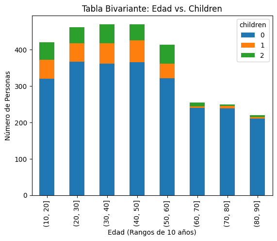

```python
# Visualizar la tabla bivariante como un gráfico de barras
tabla_bivariante.plot(kind='bar', stacked=True)
plt.xlabel('Edad (Rangos de 10 años)')
plt.ylabel('Número de Personas')
plt.title('Tabla Bivariante: Edad vs. Children')
plt.show()
```

Otro punto de vista es la cantidad de meses que este ha estado. Puede ser que nada mas entrar no les guste el servicio y se vayan. O como dije muy anteriormente haya ocurrido algo en 2023 que les haya rayado.

Entonces en esta grafica vemos algo muy interesante, y esque al pincipio hay un repunte grandisimo, eso se ve dado al tema de la permanencia. Es un gran indicativo de que como primera toma de contacto, el servicio no es grato para los clieentes. Ahora bien, pasados ya 1 año, 1 año y medio vemos como todo se estabiliza y hay una cola muy larga hacia la derecha. Que podria estar indicandonos que despues de 1 año en la compañia, la mayoria de los clientes se sienten comodos y no ven motivo alguno para abandonarla.

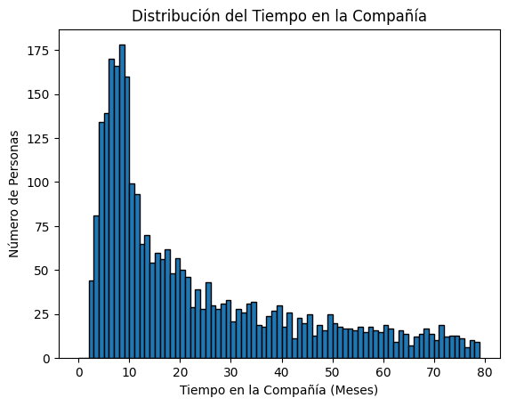

```python
import pandas as pd
import matplotlib.pyplot as plt

# Asumiendo que 'contract_date' y 'churn_date' son columnas de tipo datetime, si no, convierte las columnas antes de ejecutar esta operación
df2_not_null_churn_date['contract_date'] = pd.to_datetime(df2_not_null_churn_date['contract_date'])
df2_not_null_churn_date['churn_date'] = pd.to_datetime(df2_not_null_churn_date['churn_date'])

# Calcular la cantidad de meses que una persona ha estado en la compañía
df2_not_null_churn_date['tiempo_en_empresa_meses'] = (df2_not_null_churn_date['churn_date'] - df2_not_null_churn_date['contract_date']).astype('<m8[M]')

# Crear histograma
plt.hist(df2_not_null_churn_date['tiempo_en_empresa_meses'], bins=range(0, round(df2_not_null_churn_date['tiempo_en_empresa_meses'].max()) + 1, 1), edgecolor='black')
plt.xlabel('Tiempo en la Compañía (Meses)')
plt.ylabel('Número de Personas')
plt.title('Distribución del Tiempo en la Compañía')
plt.show()
```

```python
df1
```

|  | customerid | billing_date | monthlycharges | internetservice | onlinesecurity | onlinebackup | deviceprotection | techsupport | phone_lines | streaming |
| --- | --- | --- | --- | --- | --- | --- | --- | --- | --- | --- |
| 0 | 3d40ba9d86cc7b97612628a924cd63bc | 2023-01-31 | 29.85 | DSL | No | Yes | No | No | 0 | No |
| 19282 | 28227e725d9f3529776e6cb4e4bb352b | 2023-01-31 | 84.10 | Fiber optic | No | No | No | No | 2 | Yes |
| 71905 | 1e017bf1400190296d3c6304af03482c | 2023-01-31 | 93.55 | Fiber optic | No | No | No | No | 2 | Yes |
| 71897 | f1a5d9be8fb88920dbec1457532174a2 | 2023-01-31 | 69.50 | DSL | Yes | No | Yes | Yes | 1 | Yes |
| 19292 | 782eda53889337eee572483e2344166e | 2023-01-31 | 24.15 | No | No internet service | No internet service | No internet service | No internet service | 2 | No |
| ... | ... | ... | ... | ... | ... | ... | ... | ... | ... | ... |
| 10821 | 112f81a97681425b9be40e100d90b080 | 2023-10-31 | 25.00 | No | No internet service | No internet service | No internet service | No internet service | 2 | No |
| 32141 | 6360ed2b12c4013177c0647bfed0bff5 | 2023-10-31 | 75.00 | Fiber optic | Yes | No | No | No | 1 | No |
| 84558 | f47776e4a6e57d0bdcaa3e0b2e5adb89 | 2023-10-31 | 55.45 | DSL | Yes | Yes | No | No | 1 | No |
| 84568 | 7acf68af2960d6f41bc6ed7ec57b66a0 | 2023-10-31 | 73.44 | DSL | Yes | No | Yes | Yes | 0 | Yes |
| 40392 | f49a2d88545d7e9f9928b4a7b6420071 | 2023-10-31 | 23.88 | No | No internet service | No internet service | No internet service | No internet service | 1 | No |

100780 rows × 10 columns

# Por qué se van los clientes? Cómo podríamos frenar su marcha?

Aqui voy a tirar un poco de intuicion. Lo normal es que en las empresas de telecomunicacion al ser tan fuerte la competencial, cada una se especializa en un campo en concreto. Anteriormente vimos cual era el punto fuerte de la empresa, entonces estaria bien mirar a ver si los abandonos tienen que ver en campos donde cojea y donde a lo mejor las empresas rivales son mejores que tu.

```python
df1_filtered
```

|  | monthlycharges | internetservice | phone_lines | streaming |
| --- | --- | --- | --- | --- |
| 0 | 29.85 | DSL | 0 | No |
| 19282 | 84.10 | Fiber optic | 2 | Yes |
| 71905 | 93.55 | Fiber optic | 2 | Yes |
| 71897 | 69.50 | DSL | 1 | Yes |
| 19292 | 24.15 | No | 2 | No |
| ... | ... | ... | ... | ... |
| 10821 | 25.00 | No | 2 | No |
| 32141 | 75.00 | Fiber optic | 1 | No |
| 84558 | 55.45 | DSL | 1 | No |
| 84568 | 73.44 | DSL | 0 | Yes |
| 40392 | 23.88 | No | 1 | No |

100780 rows × 4 columns

```python
import pandas as pd

# Supongamos que df1 es tu DataFrame
# Asegúrate de que las columnas relevantes tengan el formato adecuado

# Variables relevantes
features = ['monthlycharges', 'internetservice', 'phone_lines', 'streaming']

# Filtra el DataFrame para incluir solo las columnas relevantes


# Define condiciones para segmentar
condition1 = df1['internetservice'] == 'Fiber optic'  # Puedes ajustar esto según tu necesidad
condition2 = df1['phone_lines'] > 0  # Puedes ajustar esto según tu necesidad
condition3 = df1['streaming'] == 'Yes'  # Puedes ajustar esto según tu necesidad

# Aplica las condiciones para crear segmentos
segment1 = df1[condition1 & condition2 & condition3]
segment2 = df1[~condition1 & condition2 & condition3]
segment3 = df1[condition1 & ~condition2 & condition3]
segment4 = df1[condition1 & condition2 & ~condition3]
segment5 = df1[~condition1 & ~condition2 & condition3]
segment6 = df1[condition1 & ~condition2 & ~condition3]
segment7 = df1[~condition1 & condition2 & ~condition3]
segment8 = df1[~condition1 & ~condition2 & ~condition3]

# Agrega la información de la suma de monthlycharges a cada segmento
segment1_sum = segment1['monthlycharges'].sum()
segment2_sum = segment2['monthlycharges'].sum()
segment3_sum = segment3['monthlycharges'].sum()
segment4_sum = segment4['monthlycharges'].sum()
segment5_sum = segment5['monthlycharges'].sum()
segment6_sum = segment6['monthlycharges'].sum()
segment7_sum = segment7['monthlycharges'].sum()
segment8_sum = segment8['monthlycharges'].sum()

# Crear un diccionario para mapear los segmentos con sus sumas
segment_sums = {
    'segment1': segment1_sum,
    'segment2': segment2_sum,
    'segment3': segment3_sum,
    'segment4': segment4_sum,
    'segment5': segment5_sum,
    'segment6': segment6_sum,
    'segment7': segment7_sum,
    'segment8': segment8_sum
}

# Crear una nueva columna 'ranking' en df1_filtered
df1['ranking'] = df1.apply(lambda row: min(segment_sums, key=lambda x: abs(segment_sums[x] - row['monthlycharges'])), axis=1)

# Muestra el DataFrame con la nueva columna 'ranking'

df1
```

|  | customerid | billing_date | monthlycharges | internetservice | onlinesecurity | onlinebackup | deviceprotection | techsupport | phone_lines | streaming | ranking |
| --- | --- | --- | --- | --- | --- | --- | --- | --- | --- | --- | --- |
| 0 | 3d40ba9d86cc7b97612628a924cd63bc | 2023-01-31 | 29.85 | DSL | No | Yes | No | No | 0 | No | segment6 |
| 19282 | 28227e725d9f3529776e6cb4e4bb352b | 2023-01-31 | 84.10 | Fiber optic | No | No | No | No | 2 | Yes | segment6 |
| 71905 | 1e017bf1400190296d3c6304af03482c | 2023-01-31 | 93.55 | Fiber optic | No | No | No | No | 2 | Yes | segment6 |
| 71897 | f1a5d9be8fb88920dbec1457532174a2 | 2023-01-31 | 69.50 | DSL | Yes | No | Yes | Yes | 1 | Yes | segment6 |
| 19292 | 782eda53889337eee572483e2344166e | 2023-01-31 | 24.15 | No | No internet service | No internet service | No internet service | No internet service | 2 | No | segment6 |
| ... | ... | ... | ... | ... | ... | ... | ... | ... | ... | ... | ... |
| 10821 | 112f81a97681425b9be40e100d90b080 | 2023-10-31 | 25.00 | No | No internet service | No internet service | No internet service | No internet service | 2 | No | segment6 |
| 32141 | 6360ed2b12c4013177c0647bfed0bff5 | 2023-10-31 | 75.00 | Fiber optic | Yes | No | No | No | 1 | No | segment6 |
| 84558 | f47776e4a6e57d0bdcaa3e0b2e5adb89 | 2023-10-31 | 55.45 | DSL | Yes | Yes | No | No | 1 | No | segment6 |
| 84568 | 7acf68af2960d6f41bc6ed7ec57b66a0 | 2023-10-31 | 73.44 | DSL | Yes | No | Yes | Yes | 0 | Yes | segment6 |
| 40392 | f49a2d88545d7e9f9928b4a7b6420071 | 2023-10-31 | 23.88 | No | No internet service | No internet service | No internet service | No internet service | 1 | No | segment6 |

100780 rows × 11 columns

Recordemos:

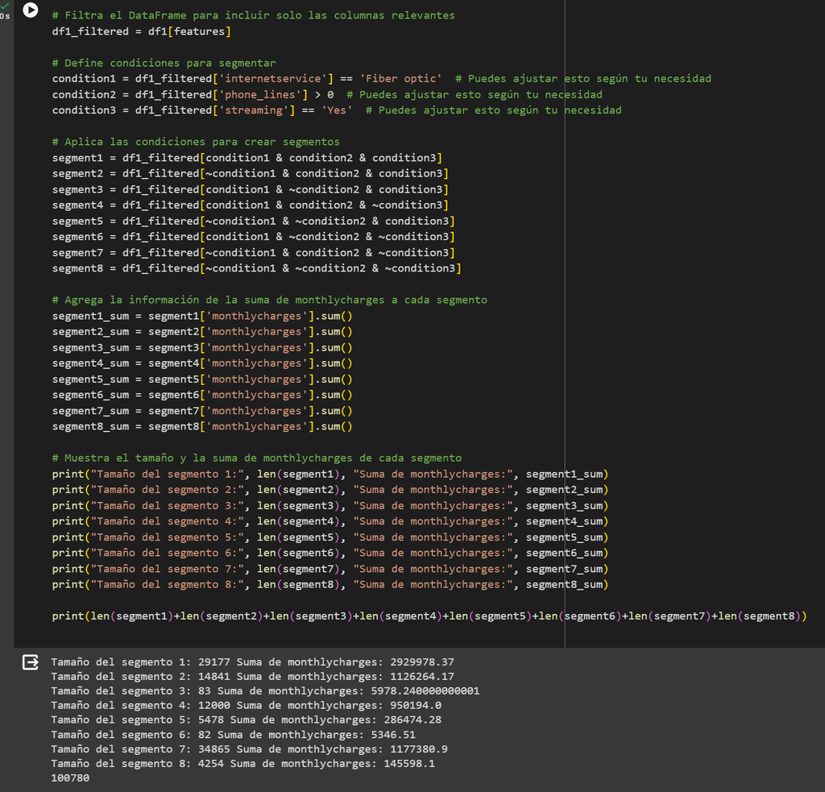

Entonces, la idea es hacer un inner join y para asi ahcer un count de si los clientes se van porque el servicio que les ofrecemos es peor que en otros sitios por ejemplo

```python
# Realizar un inner join entre df2_not_null_churn_date y df1 utilizando 'customerid' como clave
result_df = pd.merge(df2_not_null_churn_date[['customerid']], df1[['customerid', 'ranking']], on='customerid', how='inner')

# Eliminar posibles duplicados en la columna 'customerid'
result_df = result_df.drop_duplicates(subset='customerid')
result_df
```

|  | customerid | ranking |
| --- | --- | --- |
| 0 | 5cf42e9ba3bfa476bc222bebcf63f1a8 | segment6 |
| 5 | 0467f23d6b9e7891da40ed53339f5725 | segment6 |
| 13 | a3eb2b52fe0a63d2351819270bcedbf6 | segment6 |
| 22 | b6e3534f9b289114eab3721f4cf6f2f9 | segment6 |
| 25 | 34af156cf33959c65838f86c0c9b645b | segment6 |
| ... | ... | ... |
| 17960 | e8f2f4b4da13b8d358fadef0cc4d63e4 | segment6 |
| 17965 | 8de6221b3997dc1713808dcffcb437e5 | segment6 |
| 17973 | 4f7479fd8b8cb089cf02bbe3557c7656 | segment6 |
| 17979 | 70c4cda7ec0c8a1c40056b1da9f75403 | segment6 |
| 17987 | 7aea14389aa3d73fd383221574f76778 | segment6 |

2957 rows × 2 columns

```python
result_df.describe(include='all')
```

|  | customerid | ranking |
| --- | --- | --- |
| count | 2957 | 2957 |
| unique | 2957 | 2 |
| top | 5cf42e9ba3bfa476bc222bebcf63f1a8 | segment6 |
| freq | 1 | 2954 |

Aqui hacemos un grooup byu hacemos un count de cuantos habandonos han habido en cada segmento. Y grandisima sorpresa solo hay 1 segmento de 6 en el que han habido abandonos, en ninguno de los otros ha habido ni un solo abandono, excpluyendo el segmento 1 que hay 3 que eso es irrelevante. Recordemos que el segmento 6 es el punto mas debil en el que menos clientes tienen y en el que, por ende, menos dinero generan. Dando veracidad a la teoria que tenia entes,entonces, la manera o solucion que habria para retenerlos, seria o ofreciendoles ademas otro servicio o mejorando el servicio que les estas ofreciendo.

```python
# Pivoteo la columna 'ranking' y cuento cuántos customerid hay en cada categoría
pivot_table_result = result_df.pivot_table(index='ranking', aggfunc='size').reset_index(name='count')

# Mostrar el DataFrame resultante
pivot_table_result
```

|  | ranking | count |
| --- | --- | --- |
| 0 | segment1 | 3 |
| 1 | segment6 | 2954 |

Propón una campaña de retención basada en precio para el segmento más propenso y luego realiza un análisis del impacto que tendrá sobre la facturación de la compañía.

Si hablamos de retencion unicamente como tal, loq ue haria obviamente es trabajar en el unico foco de salidas que tengo. Que es el de la fibra, como tal lo que haria, en mi opnion, no es hacer una rebaja especificamente en la fibra, sino que le haria una rebaja para que entrase en otro segmento en el que se ve que funciona bien y que es el punto fuerte, un pack por asi decirlo. Por ejemplo en el segmento 4 que es el de fibra y movil.

Entonces lo que voy a hacer, es emular que ocurriria si conseguimos que esas personas pasaran al segmento 4.

```python
df1.describe(include='all')
```

|  | customerid | billing_date | monthlycharges | internetservice | onlinesecurity | onlinebackup | deviceprotection | techsupport | phone_lines | streaming | ranking |
| --- | --- | --- | --- | --- | --- | --- | --- | --- | --- | --- | --- |
| count | 100780 | 100780 | 100507.000000 | 100501 | 100575 | 100530 | 100562 | 100534 | 100780.000000 | 100780 | 100780 |
| unique | 11236 | 206 | NaN | 3 | 3 | 3 | 3 | 3 | NaN | 2 | 2 |
| top | 3d40ba9d86cc7b97612628a924cd63bc | 2023-01-31 00:00:00 | NaN | Fiber optic | No | No | No | No | NaN | No | segment6 |
| freq | 10 | 11236 | NaN | 41342 | 46562 | 41615 | 41867 | 46336 | NaN | 51201 | 100507 |
| first | NaN | 2023-01-31 00:00:00 | NaN | NaN | NaN | NaN | NaN | NaN | NaN | NaN | NaN |
| last | NaN | 2023-10-31 00:00:00 | NaN | NaN | NaN | NaN | NaN | NaN | NaN | NaN | NaN |
| mean | NaN | NaN | 65.937841 | NaN | NaN | NaN | NaN | NaN | 1.317682 | NaN | NaN |
| std | NaN | NaN | 31.834821 | NaN | NaN | NaN | NaN | NaN | 0.642785 | NaN | NaN |
| min | NaN | NaN | 18.250000 | NaN | NaN | NaN | NaN | NaN | 0.000000 | NaN | NaN |
| 25% | NaN | NaN | 30.960000 | NaN | NaN | NaN | NaN | NaN | 1.000000 | NaN | NaN |
| 50% | NaN | NaN | 70.350000 | NaN | NaN | NaN | NaN | NaN | 1.000000 | NaN | NaN |
| 75% | NaN | NaN | 91.150000 | NaN | NaN | NaN | NaN | NaN | 2.000000 | NaN | NaN |
| max | NaN | NaN | 142.380000 | NaN | NaN | NaN | NaN | NaN | 2.000000 | NaN | NaN |

Y este es el resultado de las ganancias que obtendriamos si por lo menos al segmento 6 le convencemos pasarse al segmento 4 gracias a un descuento del 20%.

```python
count_value = pivot_table_result.loc[pivot_table_result['ranking'] == 'segment6', 'count'].values[0]
print((count_value*segment4_sum/len(segment4)-segment6_sum)*0.8)
```

```
182847.66373333335
```

```python
df1.describe(include='all')
```

[output not shown]

```python
%%shell
jupyter nbconvert --to html '/content/drive/MyDrive/Colab Notebooks/Untitled8.ipynb'
```